# W4 Course Project: Exercise manner predict

WangYong

2022/2/7

# Executive Summary

In this project, your goal will be to use data from accelerometers on the belt, forearm, arm, and dumbell of **6 participants**. They were asked to perform barbell lifts correctly and incorrectly in **5 different ways**. The goal of the project is to predict the manner in which they did the exercise.

The whole process including 4 stage: 1. EDA and clean data as well as preProcess.

2. Split pre_train data into train, test, and validate part
3. Build 4 models(rpart, LDA, GBM and randomforest) based on train dataset and Use trcontrol to set cross validation by follow parameter for all models. >trainControl( method = “repeatedcv”, number = 5, ## repeated 3 times repeats = 3, verbose=TRUE )

   in order to reprduciable and avoid repeat train, the trained model will be save to file in the first time and in following traing, the save file will be load to avoid training again.
4. Compare the 4 models 3 stage (train, test and validation) accuracy leavel select random forest as best model.
5. predict 20 different test cases in pml-test

# 1. Exploratory Data Analysis and clean data

```r
library(dplyr) # data manipulate
library(caret) # machine learning
library(ggplot2) # data visualization
library(data.table) # data loading
library(lubridate) # datetime manipulate
library(moments)  # caculate moments such skew, and etc.
library(mice)  # missing value imputation
library(rattle) # fancyplot for decision tree
library(tidyr)
```

## 1.1 Load Data

load the pml-training.csv as pml-train, pml-testing.csv as pml-test.

The original data has 19622 obs, and 160 variables. ## 1.2 check the outcome by contingency table

```
##
##               A    B    C    D    E
##   adelmo   1165  776  750  515  686
##   carlitos  834  690  493  486  609
##   charles   899  745  539  642  711
##   eurico    865  592  489  582  542
##   jeremy   1177  489  652  522  562
##   pedro     640  505  499  469  497
```

It can be find there is 6 people and 5 types of exercise classes(outcome, need predict)

## 1.3 time based movement class pattern plot

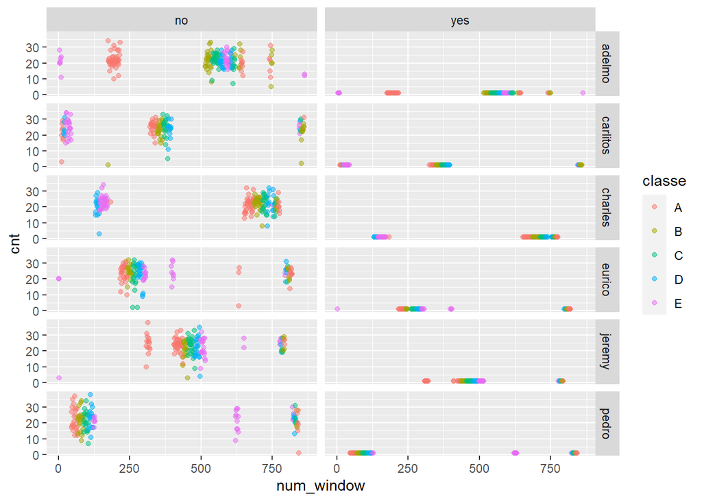

```r
ts_user_class <- pml_train %>% select(new_window,user_name,classe, cvtd_timestamp,num_window) %>%
  mutate(dt=dmy_hm(cvtd_timestamp),hour=day(dt),minute=minute(dt)) %>%
  group_by(num_window,new_window,user_name, classe) %>%
  dplyr::summarise(cnt=n())
#%>%
g<- ggplot(data=ts_user_class,aes(num_window,cnt,color=classe))
g+geom_point(alpha=0.5)+
  facet_grid(user_name~new_window)
```

For above plot, it can be find the movement class has clean pattern with sequence of num_window as well as the new_window variable. The two will be used for trainning. The raw_timestamp_part_1, raw_timestamp_part_2, and cvdt_timestamp will be removed.

## 1.4 Clean Data

### 1.4.1 drop missing value variable and keep 60 variable

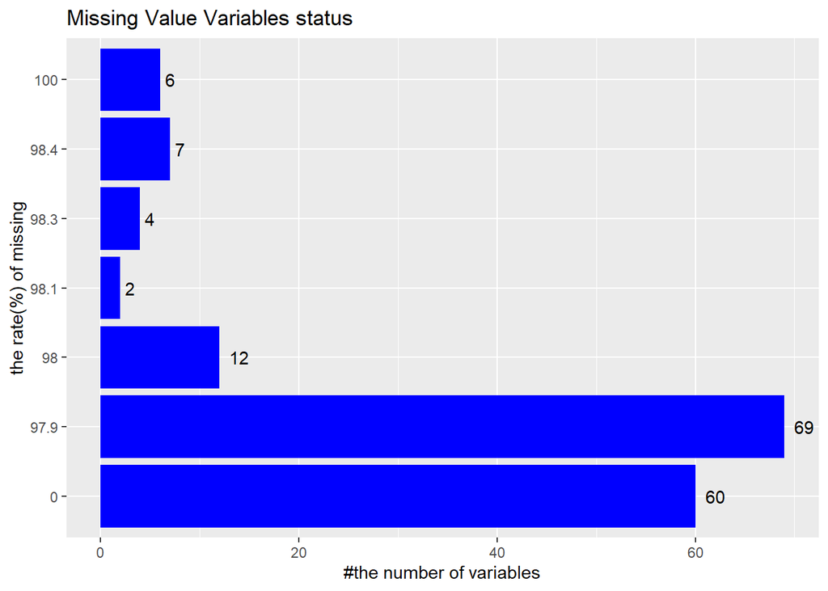

The loaded data in pml-training has 160 variable. However, 100 variables are almost missing value, the missing value rate is more than 97%. All of them will be dropped. The cleaned dataset has 60 variables.

### 1.4.2 drop/transform datime time feature

according to the time based movement classe plot, we will drop below features: - raw_timestamp_part_1, - raw_timestamp_part_2, and - cvtd_timestamp

### 1.4.3 check variable skewness

```
## [1] "gyros_dumbbell_z" "gyros_dumbbell_x" "gyros_forearm_z"  "gyros_forearm_y"
## [5] "gyros_dumbbell_y" "magnet_belt_y"
```

```r
if (!file.exists('pre_train.rds')){
  saveRDS(pre_train,'pre_train.rds')
  }else{
    pre_train <-readRDS('pre_train.rds')
    }

if (!file.exists('pre_test.rds' )) {
  saveRDS(pre_test,'pre_test.rds')
  }else{
    pre_test<-readRDS('pre_test.rds')
    }
```

# 2. Split Data into 3 piece(train, test and validate)

Now, we has slide the raw pml_train into two part:  
- train_df, which as 9619 observation. - test_df, which as 4118 observation. - validate_df, which as 5885 observation.

# 3. Build 4 Models

## 3.0 Prepare for build models

### 3.0.1 Define common functions

```r
get_model <-function(df1,target,ml_method='rpart2',var_name=NA,suffix=''){

  method <- ml_method
  model_target<-target

  if (is.na(var_name[1])){
    model_df <- df1

  } else{

    model_df <- df1 %>% select(c(var_name))
  }
  model_df <-cbind(model_df,model_target)

  model_file_name <- paste0('fit_',method,suffix,'.rds')
  if (!file.exists(model_file_name )){

    set.seed(12345)
    fitControl <- trainControl(## 10-fold CV
                               method = "repeatedcv",
                               number = 5,
                               ## repeated ten times
                               repeats = 3,
                               verbose=TRUE
                              )
    fit <- train(data=model_df,
                    model_target~.,
                    method = method,
                    trControl = fitControl)
    saveRDS(fit, model_file_name)
  } else {
    message<- paste0('loading model ',model_file_name,'  from previous file')
    print(message)
    fit<- readRDS(model_file_name)
  }

  fit
}

get_pred_accuracy<-function(ml,df,target){
  pred<-predict(ml,df)
  pred_confusionmatrix <-confusionMatrix(pred, factor(target))
  pred_confusionmatrix$overall[[1]]
}
```

### 3.0.2 find important variable by rpart method

In training stage, we will choice ‘rpart’ as the train method. our goal is classification which predict 1 of 5 movement classes based on data.

```r
method <- 'rpart2'
fit <- get_model(train_df,train_target,ml_method=method,suffix='base')
```

```
## [1] "loading model fit_rpart2base.rds  from previous file"
```

```r
pred_accuracy<- get_pred_accuracy(fit,test_df,test_target)
print(fit$method)
```

```
## [1] "rpart2"
```

```r
print(paste0('train accuracy:    ',
             round(max(fit$results$Accuracy),4),
             '    test:    ',
             round(pred_accuracy,4)))
```

```
## [1] "train accuracy:    0.6759    test:    0.6921"
```

```r
fit_rpart_base <- fit
varImp_name<-varImp(fit_rpart_base)$importance %>%
  data.frame()%>%
  filter(Overall>0)  %>%
  rownames()
```

## 3.1 model 1 - rpart

### 3.1.1 rpart build model

```r
method <- 'rpart2'

fit <- get_model(train_df,train_target,ml_method=method,suffix='')
```

```
## [1] "loading model fit_rpart2.rds  from previous file"
```

```r
pred_accuracy<- get_pred_accuracy(fit,test_df,test_target)
print(fit$method)
```

```
## [1] "rpart2"
```

```r
print(paste0('train accuracy:    ',
             round(max(fit$results$Accuracy),4),
             '    test:    ',
             round(pred_accuracy,4)))
```

```
## [1] "train accuracy:    0.6759    test:    0.6921"
```

```r
fit_rpart <-fit
```

### 3.1.2 plot rpart decison tree

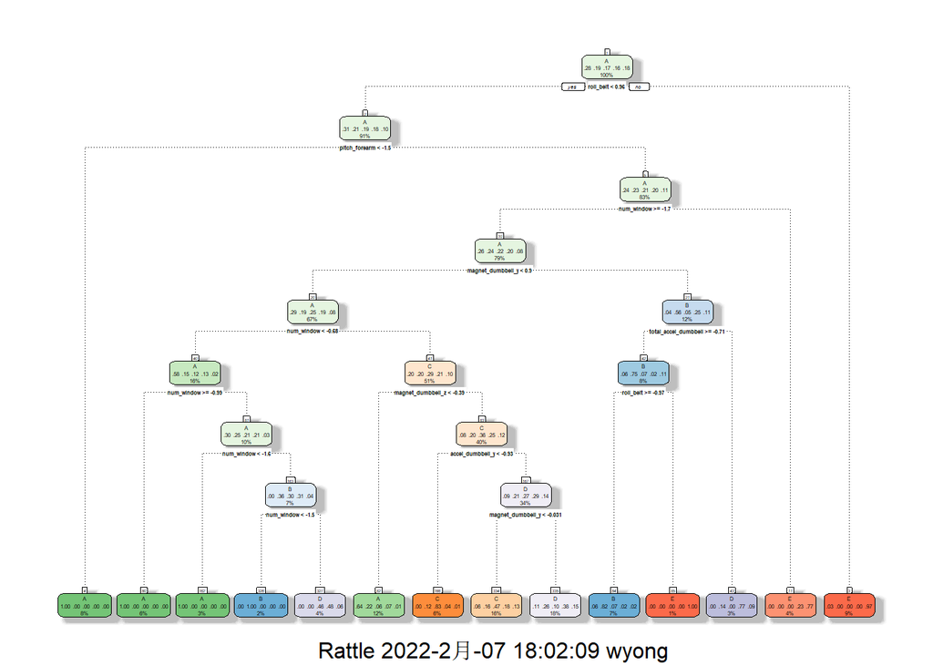

## 3.2 model 2 - LDA

```r
method <- 'lda'

fit <- get_model(train_df,train_target,ml_method=method,suffix='')
```

```
## [1] "loading model fit_lda.rds  from previous file"
```

```r
pred_accuracy<- get_pred_accuracy(fit,test_df,test_target)

print(fit$method)
```

```
## [1] "lda"
```

```r
print(paste0('train accuracy:    ',
             round(max(fit$results$Accuracy),4),
             '    test:    ',
             round(pred_accuracy,4)))
```

```
## [1] "train accuracy:    0.7125    test:    0.7096"
```

```r
fit_lda <- fit
```

## 3.3 model3 - gbm

### 3.3.1 gbm model build

```r
method = 'gbm'


fit <- get_model(train_df,train_target,ml_method=method,suffix='')
```

```
## [1] "loading model fit_gbm.rds  from previous file"
```

```r
pred_accuracy<- get_pred_accuracy(fit,test_df,test_target)
print(fit$method)
```

```
## [1] "gbm"
```

```r
print(paste0('train accuracy:    ',
             round(max(fit$results$Accuracy),4),
             '    test:    ',
             round(pred_accuracy,4)))
```

```
## [1] "train accuracy:    0.9831    test:    0.9893"
```

```r
fit_gbm <- fit
```

## 3.3.2 gbm model accuracy CV iterations plot

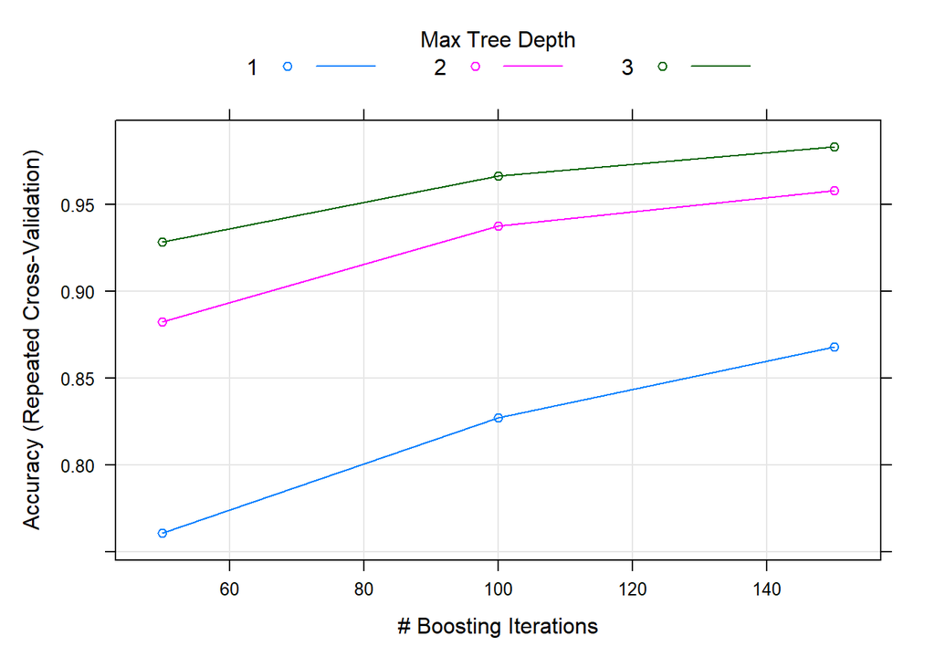

## 3.4 model4 - random forerest ### 3.4.1 random forest model build

```r
method = 'rf'

fit <- get_model(train_df,train_target,ml_method=method,suffix='')
```

```
## [1] "loading model fit_rf.rds  from previous file"
```

```r
pred_accuracy<- get_pred_accuracy(fit,test_df,test_target)
print(fit$method)
```

```
## [1] "rf"
```

```r
print(paste0('train accuracy:    ',
             round(max(fit$results$Accuracy),4),
             '    test:    ',
             round(pred_accuracy,4)))
```

```
## [1] "train accuracy:    0.9944    test:    0.9968"
```

```r
fit_rf <- fit
```